# Módulo 5 - Técnicas de Programação II | Python

Crie um gráfico de sua escolha, que mostre o total de medalhas de ouro, prata e bronze, por edição da olimpíada (em ordem cronológica).

*DICA:* Mais uma vez, tome cuidado com os esportes em grupo - os contabilize apenas uma vez!

```python
years_medals = df1[df1['Sport'].isin(['Judo','Boxing','Swimming','Taekwondo','Shooting','Athletics'])].groupby(['Year'])['Medal'].value_counts().unstack().fillna(0)
years_medals
```

| Medal Year | Bronze | Gold | Silver |
| --- | --- | --- | --- |
| 1920 | 5.0 | 1.0 | 1.0 |
| 1952 | 2.0 | 1.0 | 0.0 |
| 1956 | 0.0 | 1.0 | 0.0 |
| 1960 | 1.0 | 0.0 | 0.0 |
| 1968 | 1.0 | 0.0 | 1.0 |
| 1972 | 2.0 | 0.0 | 0.0 |
| 1976 | 1.0 | 0.0 | 0.0 |
| 1980 | 5.0 | 0.0 | 0.0 |
| 1984 | 2.0 | 1.0 | 2.0 |
| 1988 | 1.0 | 1.0 | 1.0 |
| 1992 | 0.0 | 1.0 | 1.0 |
| 1996 | 8.0 | 0.0 | 1.0 |
| 2000 | 4.0 | 0.0 | 7.0 |
| 2004 | 3.0 | 0.0 | 0.0 |
| 2008 | 9.0 | 2.0 | 0.0 |
| 2012 | 6.0 | 1.0 | 2.0 |
| 2016 | 4.0 | 3.0 | 1.0 |

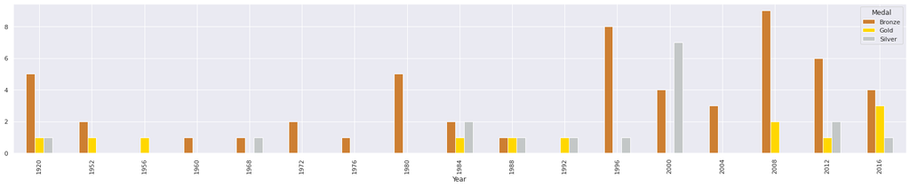

```python
stacked_fig = years_medals.plot(kind='bar',  color=['#CD7F32' , '#FFD700' , '#C3C7C7'])
```

**5. Agora é com vocês!**

Escolha uma análise visual que julga interessante de fazer neste conjunto de dados, faça o(s) gráficos(s) necessários e comente os resultados.

```python
Medals = df1['Medal'].value_counts()
Medals
```

```
Bronze    185
Silver    161
Gold      103
Name: Medal, dtype: int64
```

[figure not shown]

```python
explode = (0.05, 0.05 , 0.05)
color=['#CD7F32' , '#FFD700' , '#C3C7C7']
plt.pie(Medals , labels = ['Gold' , 'Bronze' , 'Silver'] , autopct="%.2f" , explode = explode, pctdistance=0.85 , colors = color)
centre_circle = plt.Circle((0, 0), 0.70, fc='white')
fig = plt.gcf()

fig.gca().add_artist(centre_circle)
plt.legend(title = 'Medals' , bbox_to_anchor =(0.30, 1.05), ncol = 3 , loc = 'lower left')
plt.title('the Percentage of each medal awarded' , loc = 'center');
```

```python
print("TOTAL PLAYERS -->",len(df1.ID.unique()))
```

```
TOTAL PLAYERS --> 2011
```

```python
import matplotlib.pyplot as pyplot
```

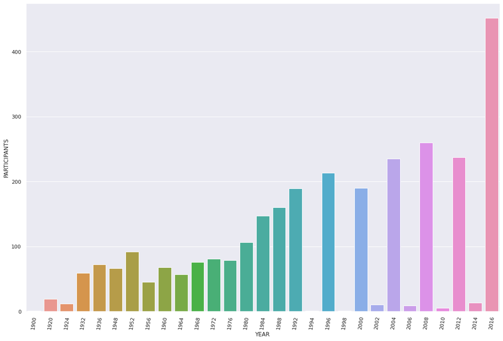

```python
sns.set(rc={'figure.figsize':(18,12)})
plot1 = sns.barplot(x='Year',y='ID',data=groupedYearID).set_xticklabels(groupedYearID.Year,rotation=82)
pyplot.xlabel("YEAR")
pyplot.ylabel("PARTICIPANTS");
```

```python
import warnings
warnings.filterwarnings('ignore')
```

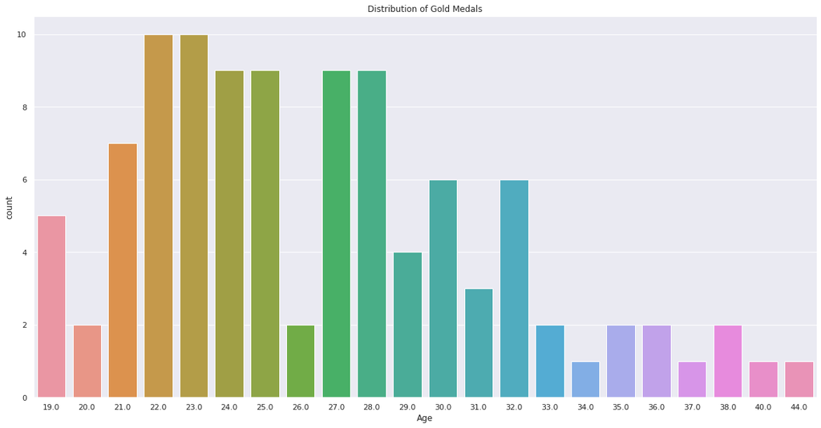

```python
goldMedals = df1[(df1.Medal == 'Gold')]
#goldMedals.isnull().any()
goldMedals = goldMedals[np.isfinite(goldMedals['Age'])]

plt.figure(figsize=(20, 10))
plt.tight_layout()
sns.countplot(goldMedals['Age']);
plt.title('Distribution of Gold Medals');
```

```python
goldMedals['ID'][goldMedals['Age'] > 19].count()
```

```
98
```

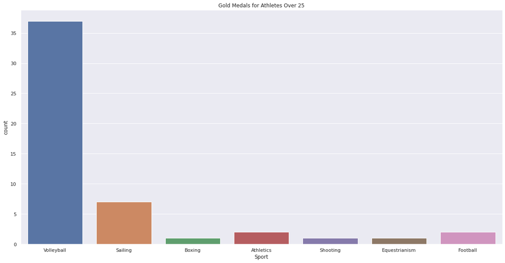

```python
masterDisciplines = goldMedals['Sport'][goldMedals['Age'] > 25]
plt.figure(figsize=(20, 10))
plt.tight_layout()
sns.countplot(masterDisciplines)
plt.title('Gold Medals for Athletes Over 25')
```

```python
df1.Name.value_counts()[:15]
```

```
Daniele Matias Hyplito                           24
Srgio Yoshio Sasaki Jnior                        14
Gustavo Frana Borges                             13
Rodrigo de Paula Pessoa                          12
Hugo Hoyama                                      11
Daiane Garcia dos Santos                         11
Jorge Luiz Fernandes Leite                       11
Camila Comin                                     11
Jade Fernandes Barbosa                           11
Joanna de Albuquerque Maranho Bezerra de Melo    11
Lusa Parente Ribeiro de Carvalho                 10
Ethiene Cristina Gonser Franco                   10
Alvaro Affonso "Doda" de Miranda Neto            10
Las da Silva Souza                               10
Rogrio Aoki Romero                               10
Name: Name, dtype: int64
```

```python
df1[(df1['Name'] == 'Daniele Matias Hyplito')& (df1.allmedals == 1)]
```

|  | ID | Name | Sex | Age | Height | Weight | Team | NOC | Games | Year | Season | City | Sport | Event | Medal | Bronze | Gold | Silver | allmedals |
| --- | --- | --- | --- | --- | --- | --- | --- | --- | --- | --- | --- | --- | --- | --- | --- | --- | --- | --- | --- |

```python
df1[(df1['Name'] == 'Gustavo Frana Borges')& (df1.allmedals == 1)]
```

|  | ID | Name | Sex | Age | Height | Weight | Team | NOC | Games | Year | Season | City | Sport | Event | Medal | Bronze | Gold | Silver | allmedals |
| --- | --- | --- | --- | --- | --- | --- | --- | --- | --- | --- | --- | --- | --- | --- | --- | --- | --- | --- | --- |
| 25790 | 13462 | Gustavo Frana Borges | M | 19.0 | 203.0 | 98.0 | Brazil | BRA | 1992 Summer | 1992 | Summer | Barcelona | Swimming | Swimming Men's 100 metres Freestyle | Silver | 0 | 0 | 1 | 1 |
| 25795 | 13462 | Gustavo Frana Borges | M | 23.0 | 203.0 | 98.0 | Brazil | BRA | 1996 Summer | 1996 | Summer | Atlanta | Swimming | Swimming Men's 100 metres Freestyle | Bronze | 1 | 0 | 0 | 1 |
| 25796 | 13462 | Gustavo Frana Borges | M | 23.0 | 203.0 | 98.0 | Brazil | BRA | 1996 Summer | 1996 | Summer | Atlanta | Swimming | Swimming Men's 200 metres Freestyle | Silver | 0 | 0 | 1 | 1 |
| 25799 | 13462 | Gustavo Frana Borges | M | 27.0 | 203.0 | 98.0 | Brazil | BRA | 2000 Summer | 2000 | Summer | Sydney | Swimming | Swimming Men's 4 x 100 metres Freestyle Relay | Bronze | 1 | 0 | 0 | 1 |

```python
medals = df1.groupby('Name',as_index=False).sum()
```

```python
mostmed = medals.sort_values(by=['allmedals'],ascending=False)
```

```python
mostmed.head(10)[['Name','Bronze','Gold','Silver','allmedals']]
```

|  | Name | Bronze | Gold | Silver | allmedals |
| --- | --- | --- | --- | --- | --- |
| 1658 | Robert Scheidt | 1 | 2 | 2 | 5 |
| 1883 | Torben Schmidt Grael | 2 | 2 | 1 | 5 |
| 784 | Gustavo Frana Borges | 2 | 0 | 2 | 4 |
| 1799 | Srgio "Escadinha" Dutra dos Santos | 0 | 2 | 2 | 4 |
| 449 | Dante Guimares Santos do Amaral | 0 | 1 | 2 | 3 |
| 1676 | Rodrigo "Rodrigo" Santana | 0 | 1 | 2 | 3 |
| 737 | Gilberto Amauri "Giba" de Godoy Filho | 0 | 1 | 2 | 3 |
| 413 | Csar Augusto Cielo Filho | 2 | 1 | 0 | 3 |
| 1686 | Rodrigo de Paula Pessoa | 2 | 1 | 0 | 3 |
| 837 | Hlia "Fofo" Rogrio de Souza Pinto | 2 | 1 | 0 | 3 |

```python
df1[(df1['Name'] == 'Robert Scheidt')& (df1.allmedals == 1)]
```

|  | ID | Name | Sex | Age | Height | Weight | Team | NOC | Games | Year | Season | City | Sport | Event | Medal | Bronze | Gold | Silver | allmedals |
| --- | --- | --- | --- | --- | --- | --- | --- | --- | --- | --- | --- | --- | --- | --- | --- | --- | --- | --- | --- |
| 212472 | 106683 | Robert Scheidt | M | 23.0 | 188.0 | 76.0 | Brazil | BRA | 1996 Summer | 1996 | Summer | Atlanta | Sailing | Sailing Mixed One Person Dinghy | Gold | 0 | 1 | 0 | 1 |
| 212473 | 106683 | Robert Scheidt | M | 27.0 | 188.0 | 76.0 | Brazil | BRA | 2000 Summer | 2000 | Summer | Sydney | Sailing | Sailing Mixed One Person Dinghy | Silver | 0 | 0 | 1 | 1 |
| 212474 | 106683 | Robert Scheidt | M | 31.0 | 188.0 | 76.0 | Brazil | BRA | 2004 Summer | 2004 | Summer | Athina | Sailing | Sailing Mixed One Person Dinghy | Gold | 0 | 1 | 0 | 1 |
| 212475 | 106683 | Robert Scheidt | M | 35.0 | 188.0 | 76.0 | Brazil | BRA | 2008 Summer | 2008 | Summer | Beijing | Sailing | Sailing Men's Two Person Keelboat | Silver | 0 | 0 | 1 | 1 |
| 212476 | 106683 | Robert Scheidt | M | 39.0 | 188.0 | 76.0 | Brazil | BRA | 2012 Summer | 2012 | Summer | London | Sailing | Sailing Men's Two Person Keelboat | Bronze | 1 | 0 | 0 | 1 |

```python
mostgold = medals.sort_values(by=['Gold'],ascending=False)
mostgold.head(10)[['Name','Gold']]
```

|  | Name | Gold |
| --- | --- | --- |
| 604 | Fabiana "Fabi" Alvim de Oliveira | 2 |
| 748 | Giovane Farinazzo Gvio | 2 |
| 1858 | Thasa Daher de Menezes | 2 |
| 1883 | Torben Schmidt Grael | 2 |
| 908 | Jaqueline Maria "Jaque" Pereira de Carvalho En... | 2 |
| 1658 | Robert Scheidt | 2 |
| 1799 | Srgio "Escadinha" Dutra dos Santos | 2 |
| 607 | Fabiana Marcelino Claudino | 2 |
| 1768 | Sheilla Tavares de Castro Blassioli | 2 |
| 1526 | Paula Renata Marques Pequeno | 2 |

```python
df1[df1.Age ==df1.Age.min()]
```

|  | ID | Name | Sex | Age | Height | Weight | Team | NOC | Games | Year | Season | City | Sport | Event | Medal | Bronze | Gold | Silver | allmedals |
| --- | --- | --- | --- | --- | --- | --- | --- | --- | --- | --- | --- | --- | --- | --- | --- | --- | --- | --- | --- |
| 202471 | 101697 | Talita de Alencar Rodrgues | F | 13.0 | NaN | NaN | Brazil | BRA | 1948 Summer | 1948 | Summer | London | Swimming | Swimming Women's 4 x 100 metres Freestyle Relay | NaN | 0 | 0 | 0 | 0 |

```python
df1[df1.Age ==df1.Age.max()]
```

|  | ID | Name | Sex | Age | Height | Weight | Team | NOC | Games | Year | Season | City | Sport | Event | Medal | Bronze | Gold | Silver | allmedals |
| --- | --- | --- | --- | --- | --- | --- | --- | --- | --- | --- | --- | --- | --- | --- | --- | --- | --- | --- | --- |
| 186471 | 93749 | Nelson Pessoa Filho | M | 56.0 | 175.0 | 65.0 | Brazil | BRA | 1992 Summer | 1992 | Summer | Barcelona | Equestrianism | Equestrianism Mixed Jumping, Individual | NaN | 0 | 0 | 0 | 0 |
| 186472 | 93749 | Nelson Pessoa Filho | M | 56.0 | 175.0 | 65.0 | Brazil | BRA | 1992 Summer | 1992 | Summer | Barcelona | Equestrianism | Equestrianism Mixed Jumping, Team | NaN | 0 | 0 | 0 | 0 |